# DS340W PARENT PAPER CODE IMPLEMENTATION

JACOB HURLEY

1/22/23

```r
# clean up workspace environment
rm(list = ls())
knitr::opts_chunk$set(fig.width=8, fig.height=12)

# all packages used for the assignment
library(tidyverse)
library(rjson)
library(jsonlite)
```

## First, load in the data sets

```r
kPlaylists <- read.csv("kaggle_playlists.csv")
kPlaylistsGenre <- read.csv("kaggle_genres.csv")
sPlaylists <- fromJSON("spotify1.json")[[2]]
sPlaylists2 <- fromJSON("spotify2.json")[[2]]
sPlaylistsTotal <- bind_rows(sPlaylists, sPlaylists2)
```

## Here, create a NULL data frame to be used later on

```r
AvgData <- data.frame(NULL)
```

## Playlists’ Number of Tracks vs Time (minutes) Classified by is collaborative or not

Here is a quick view of the Spotify Data set visualized by a graph:

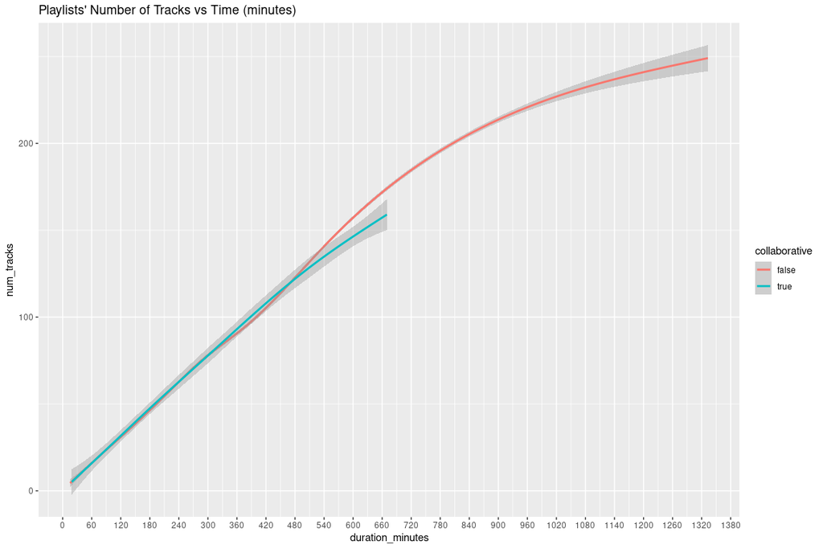

```r
# first graph seen here
sPlaylistsTotal %>%
  mutate(duration_minutes = duration_ms/60000) %>%
  ggplot(aes(x = duration_minutes, y = num_tracks)) +
  aes(colour = collaborative) +
  ggtitle("Playlists' Number of Tracks vs Time (minutes)") +
  geom_smooth() +
  scale_x_continuous(breaks=seq(0,1600,60)) #mess with figure width
```

Notice how the collaborative playlists stick to the trend of non collaborative playlists very well, so considering both collaborative and non collaborative playlists is valid. Note: Most collaborative playlists do not exceed over 680 minutes. Afterwords, you have playlists that are only non-collaborative. There is also a correlation with total songs in a playlist with total duration in minutes.

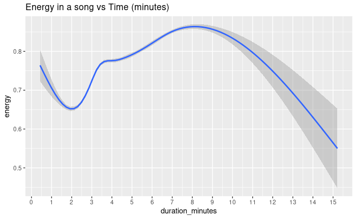

```r
kPlaylistsGenre %>%
  mutate(duration_minutes = duration_ms/60000) %>%
  ggplot(aes(x = duration_minutes, y = energy)) +
  ggtitle("Energy in a song vs Time (minutes)") +
  geom_smooth() +
  scale_x_continuous(breaks=seq(0,15,1))
```

# danceability

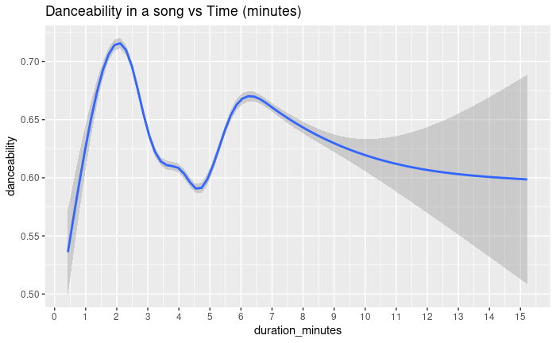

```r
kPlaylistsGenre %>%
  mutate(duration_minutes = duration_ms/60000) %>%
  ggplot(aes(x = duration_minutes, y = danceability)) +
  ggtitle("Danceability in a song vs Time (minutes)") +
  geom_smooth() +
  scale_x_continuous(breaks=seq(0,15,1))
```

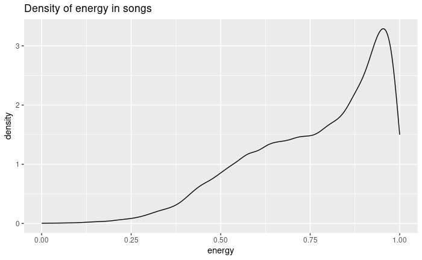

```r
ggplot(kPlaylistsGenre, aes(energy)) +
  ggtitle("Density of energy in songs") +
  geom_density()
```

# danceability

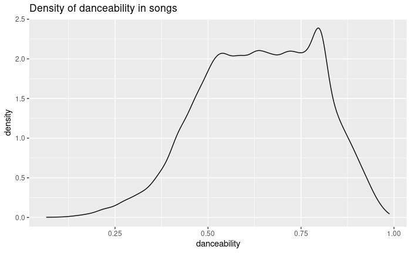

```r
ggplot(kPlaylistsGenre, aes(danceability)) +
  ggtitle("Density of danceability in songs") +
  geom_density()
```

## Function Defined

Here we have a function that will calculate the averages of a given playlist

```r
averages <- function(duration_ms, num_tracks) {
  AvgTime <- mean(duration_ms/60000)
  AvgSongs <- mean(num_tracks)
  AvgSongLength <- AvgTime/AvgSongs
  return(c(AvgTime, AvgSongs, AvgSongLength))
}
```

## Calculating: Averages (no filter)

Firstly, find the overall averages of the whole data set to compare later on.

```r
AvgData <- rbind(AvgData, c(averages(sPlaylistsTotal$duration_ms, sPlaylistsTotal$num_tracks), "No Filter"))
#print("The ideal playlist is 66 songs long, totaling 4 hours and 20 minutes in time. This then averages to 3 minutes and 55 seconds for each song.")
```

## Calculating: Averages, Filtered by Hiphop

Here, grepl is used to filter out only playlists with the title “hiphop” involved. This will then give us the averages of the playlists only containing the word “hiphop”

```r
hiphop_filtered <- sPlaylistsTotal %>%
  filter(grepl("hiphop", name, ignore.case = TRUE))
AvgData <- rbind(AvgData,  c(averages(hiphop_filtered$duration_ms, hiphop_filtered$num_tracks), "hiphop"))
```

## Calculating: Averages, Filtered by Chill

Here is another look at another key word, “Chill”. Chill playlists are found to be longer and have longer song lengths. These playlists tend to feature songs with lower energy, regardless of length.

```r
chill_filtered <- sPlaylistsTotal %>%
  filter(grepl("chill", name, ignore.case = TRUE))
AvgData <- rbind(AvgData,  c(averages(chill_filtered$duration_ms, chill_filtered$num_tracks), "Chill"))
colnames(AvgData) <- c("Time_in_Minutes", "Songs_in_Playlist", "Song_Length_Minutes","Catagory")
```

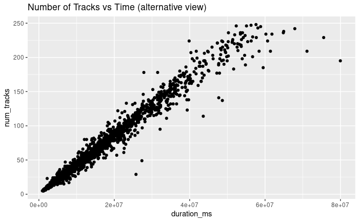

```r
AvgPlot <-
  ggplot(data=sPlaylistsTotal, aes(x=duration_ms, y=num_tracks)) +
  ggtitle("Number of Tracks vs Time (alternative view)") +
  geom_point(stat="identity")
AvgPlot
```

## Calculating: Averages, Filtered by Rap

```r
rap_filtered <- sPlaylistsTotal %>%
  filter(grepl("rap", name, ignore.case = TRUE))
AvgData <- rbind(AvgData,  c(averages(rap_filtered$duration_ms, rap_filtered$num_tracks), "Rap"))
colnames(AvgData) <- c("Time_in_Minutes", "Songs_in_Playlist", "Song_Length_Minutes","Catagory")
show(rap_filtered)
```

| name | collaborative | pid | modified_at | num_tracks | num_albums | num_followers | tracks | num_edits | duration_ms | num_artists | description |
| --- | --- | --- | --- | --- | --- | --- | --- | --- | --- | --- | --- |
| Rap | false | 2002 | 1509235200 | 221 | 128 | 4 |  | 65 | 47356150 | 84 | NA |
| Rap | false | 2009 | 1462492800 | 19 | 16 | 1 |  | 4 | 5102067 | 10 | NA |
| Chill Rap | false | 2021 | 1509235200 | 73 | 56 | 1 |  | 39 | 16160161 | 37 | NA |
| Rap | false | 2023 | 1507248000 | 13 | 12 | 1 |  | 8 | 3309944 | 6 | NA |
| rappy | false | 2067 | 1434499200 | 89 | 49 | 1 |  | 38 | 21482027 | 40 | NA |
| Rap | false | 2103 | 1499040000 | 59 | 27 | 1 |  | 7 | 14844042 | 21 | NA |
| Hip Hop/Rap | false | 2205 | 1509408000 | 176 | 104 | 2 |  | 63 | 41700671 | 60 | NA |
| Rap | false | 2231 | 1445558400 | 191 | 34 | 1 |  | 17 | 47710260 | 16 | NA |
| hip hop / rap | false | 2322 | 1509321600 | 114 | 80 | 1 |  | 89 | 24740803 | 45 | NA |
| Rap | false | 2382 | 1509408000 | 48 | 38 | 1 |  | 22 | 11697979 | 26 | NA |

[output cut: 34 more lines]

## A For loop to Cycle Through Each Row in AvgData (no filter, hiphop, chill, rap)

```r
for (i in 1:nrow(AvgData)) {
      print(paste("the average playlist length in minutes for", AvgData$Catagory[i], "is:", AvgData$Time_in_Minutes[i], "the average playlist length in songs", AvgData$Catagory[i], " is:", AvgData$Songs_in_Playlist[i], "the average song length for", AvgData$Catagory[i], "is:", AvgData$Song_Length_Minutes[i]))
}
```

```
[1] "the average playlist length in minutes for No Filter is: 259.051164533333 the average playlist length in songs No Filter  is: 66.1305 the average song length for No Filter is: 3.91727212909827"
[1] "the average playlist length in minutes for hiphop is: 417.685958333333 the average playlist length in songs hiphop  is: 105 the average song length for hiphop is: 3.97796150793651"
[1] "the average playlist length in minutes for Chill is: 338.672039873418 the average playlist length in songs Chill  is: 84.4556962025316 the average song length for Chill is: 4.0100556279976"
[1] "the average playlist length in minutes for Rap is: 327.082179545455 the average playlist length in songs Rap  is: 83.3863636363636 the average song length for Rap is: 3.92249002452984"
```

# Average Rap/Hiphop/Chill playlist found

Now that we have values for these associated genres, we can calculate averages of these playlists length in songs, time and individual song time. We can say then for us to create a playlist to suggest to the “rap” category must be within a few degrees of 327 total minutes of listen time and 83 songs in total. Each song will average nearly 4 minutes in length total.

# Creating new playlists by filtering “RnB”, A genre associated with Rap and Danceablility

After our recent findings with the Spotify data set and the genre “rap”, lets take a look at how we can now suggest new playlists to users based off of their input. We will look at the genre associated with rap, “RnB” and filter by it first.

# User Filters by RnB first

```r
#user input would be "Rnb"
RnB_filtered <- kPlaylistsGenre %>%
  filter(grepl("RnB", genre, ignore.case = TRUE))
AvgData <- rbind(AvgData,  c(averages(hiphop_filtered$duration_ms, hiphop_filtered$num_tracks), "RnB"))
show(RnB_filtered)
```

| danceability | energy | key | loudness | mode | speechiness | acousticness | instrumentalness | liveness | valence | tempo | type | id | uri | track_href | analysis_url | duration_ms | time_signature | genre | song_name | Unnamed..0 | title |
| --- | --- | --- | --- | --- | --- | --- | --- | --- | --- | --- | --- | --- | --- | --- | --- | --- | --- | --- | --- | --- | --- |
| 0.602 | 0.7850 | 7 | -6.129 | 1 | 0.0578 | 0.245000 | 0.00e+00 | 0.1900 | 0.5650 | 168.076 | audio_features | 2J56xal7OfAlClcJymx8p4 | spotify:track:2J56xal7OfAlClcJymx8p4 | https://api.spotify.com/v1/tracks/2J56xal7OfAlClcJymx8p4 | https://api.spotify.com/v1/audio-analysis/2J56xal7OfAlClcJymx8p4 | 214480 | 4 | RnB | I Need a Girl | NA |  |
| 0.622 | 0.5930 | 7 | -8.352 | 0 | 0.0916 | 0.163000 | 0.00e+00 | 0.0979 | 0.6070 | 188.728 | audio_features | 5WphWTUIfRe7x8NZss79cY | spotify:track:5WphWTUIfRe7x8NZss79cY | https://api.spotify.com/v1/tracks/5WphWTUIfRe7x8NZss79cY | https://api.spotify.com/v1/audio-analysis/5WphWTUIfRe7x8NZss79cY | 249093 | 4 | RnB | Let Me Love You | NA |  |
| 0.717 | 0.5830 | 1 | -5.008 | 1 | 0.1460 | 0.506000 | 0.00e+00 | 0.0821 | 0.8160 | 139.760 | audio_features | 6OSmeoh8kXhCfz9WqvzDoJ | spotify:track:6OSmeoh8kXhCfz9WqvzDoJ | https://api.spotify.com/v1/tracks/6OSmeoh8kXhCfz9WqvzDoJ | https://api.spotify.com/v1/audio-analysis/6OSmeoh8kXhCfz9WqvzDoJ | 252933 | 4 | RnB | Same Girl (with Usher) | NA |  |
| 0.819 | 0.5060 | 1 | -4.965 | 1 | 0.0479 | 0.376000 | 0.00e+00 | 0.0945 | 0.6080 | 199.942 | audio_features | 74r0nwfhQyQ5vPYjDoEuve | spotify:track:74r0nwfhQyQ5vPYjDoEuve | https://api.spotify.com/v1/tracks/74r0nwfhQyQ5vPYjDoEuve | https://api.spotify.com/v1/audio-analysis/74r0nwfhQyQ5vPYjDoEuve | 287947 | 4 | RnB | Me & U (feat. Diddy & Yung Joc) - Remix | NA |  |
| 0.662 | 0.7480 | 5 | -3.041 | 0 | 0.2680 | 0.688000 | 8.43e-06 | 0.0841 | 0.5350 | 164.662 | audio_features | 6Nq5lE0CeOAAAqN4qhkbZU | spotify:track:6Nq5lE0CeOAAAqN4qhkbZU | https://api.spotify.com/v1/tracks/6Nq5lE0CeOAAAqN4qhkbZU | https://api.spotify.com/v1/audio-analysis/6Nq5lE0CeOAAAqN4qhkbZU | 239027 | 4 | RnB | Suga Suga | NA |  |
| 0.727 | 0.5520 | 2 | -8.074 | 0 | 0.1400 | 0.227000 | 1.64e-04 | 0.1980 | 0.6070 | 168.189 | audio_features | 0ARK753YaiJbpLUk7z5yIM | spotify:track:0ARK753YaiJbpLUk7z5yIM | https://api.spotify.com/v1/tracks/0ARK753YaiJbpLUk7z5yIM | https://api.spotify.com/v1/audio-analysis/0ARK753YaiJbpLUk7z5yIM | 289160 | 4 | RnB | Dilemma | NA |  |
| 0.675 | 0.3940 | 8 | -8.539 | 1 | 0.1330 | 0.061100 | 0.00e+00 | 0.2140 | 0.4050 | 209.974 | audio_features | 5kxddRG1RZaZROadk7iC4D | spotify:track:5kxddRG1RZaZROadk7iC4D | https://api.spotify.com/v1/tracks/5kxddRG1RZaZROadk7iC4D | https://api.spotify.com/v1/audio-analysis/5kxddRG1RZaZROadk7iC4D | 238800 | 4 | RnB | Bartender | NA |  |
| 0.659 | 0.6960 | 3 | -4.291 | 1 | 0.0710 | 0.143000 | 0.00e+00 | 0.1300 | 0.6650 | 172.002 | audio_features | 1j3H54xdahpAkNI0q6S89q | spotify:track:1j3H54xdahpAkNI0q6S89q | https://api.spotify.com/v1/tracks/1j3H54xdahpAkNI0q6S89q | https://api.spotify.com/v1/audio-analysis/1j3H54xdahpAkNI0q6S89q | 252160 | 4 | RnB | With You | NA |  |
| 0.772 | 0.5870 | 6 | -6.944 | 1 | 0.1870 | 0.069700 | 0.00e+00 | 0.2520 | 0.7550 | 168.050 | audio_features | 1cb7x6ypOTkoY9naUUddYQ | spotify:track:1cb7x6ypOTkoY9naUUddYQ | https://api.spotify.com/v1/tracks/1cb7x6ypOTkoY9naUUddYQ | https://api.spotify.com/v1/audio-analysis/1cb7x6ypOTkoY9naUUddYQ | 238467 | 4 | RnB | Outta My System | NA |  |
| 0.662 | 0.5070 | 5 | -8.238 | 1 | 0.1180 | 0.257000 | 0.00e+00 | 0.0465 | 0.6760 | 172.824 | audio_features | 68vgtRHr7iZHpzGpon6Jlo | spotify:track:68vgtRHr7iZHpzGpon6Jlo | https://api.spotify.com/v1/tracks/68vgtRHr7iZHpzGpon6Jlo | https://api.spotify.com/v1/audio-analysis/68vgtRHr7iZHpzGpon6Jlo | 223440 | 4 | RnB | My Boo | NA |  |

[output cut: 990 more lines]